# Introduction

This is a dataset of the elo of every NBA game from the 2022-2023 season. Elo is used to measure the relative strength of every game. Raptor is is a plus-minus statistic that measures the number of points a player contributes to his team’s offense and defense per 100 possessions, relative to a league-average player. A team's raptor score is essentially an aggregate of the raptor ratings of all of the players on the team. The dataset came from https://data.fivethirtyeight.com/ and they compiled it using information from Basketball-Reference.com

```python
import numpy as np
import pandas as pd
import seaborn as sns
#code to import the data from a local file
elo = pd.read_csv("nba_elo_latest (1).csv")
elo.head()
```

|  | date | season | neutral | playoff | team1 | team2 | elo1_pre | elo2_pre | elo_prob1 | elo_prob2 | ... | carm-elo2_post | raptor1_pre | raptor2_pre | raptor_prob1 | raptor_prob2 | score1 | score2 | quality | importance | total_rating |
| --- | --- | --- | --- | --- | --- | --- | --- | --- | --- | --- | --- | --- | --- | --- | --- | --- | --- | --- | --- | --- | --- |
| 0 | 2022-10-18 | 2023 | 0 | NaN | BOS | PHI | 1657.639749 | 1582.247327 | 0.732950 | 0.267050 | ... | NaN | 1693.243079 | 1641.876729 | 0.670612 | 0.329388 | 126 | 117 | 96 | 13 | 55 |
| 1 | 2022-10-18 | 2023 | 0 | NaN | GSW | LAL | 1660.620307 | 1442.352444 | 0.862011 | 0.137989 | ... | NaN | 1615.718147 | 1472.173711 | 0.776502 | 0.223498 | 123 | 109 | 67 | 20 | 44 |
| 2 | 2022-10-19 | 2023 | 0 | NaN | IND | WAS | 1399.201934 | 1440.077372 | 0.584275 | 0.415725 | ... | NaN | 1462.352663 | 1472.018225 | 0.599510 | 0.400490 | 107 | 114 | 37 | 28 | 33 |
| 3 | 2022-10-19 | 2023 | 0 | NaN | DET | ORL | 1393.525172 | 1366.089249 | 0.675590 | 0.324410 | ... | NaN | 1308.969909 | 1349.865183 | 0.563270 | 0.436730 | 113 | 109 | 3 | 1 | 2 |
| 4 | 2022-10-19 | 2023 | 0 | NaN | ATL | HOU | 1535.408152 | 1351.164973 | 0.837022 | 0.162978 | ... | NaN | 1618.256817 | 1283.328356 | 0.917651 | 0.082349 | 117 | 107 | 24 | 1 | 13 |

5 rows × 27 columns

# Preprocessing

I reomved the neutral column because it didn't seem meaningful, especially since there were only 2 games played at neutral sites. I also removed the carm-elo columns because a lot of the values for carm-elo_prob1 were missing so I didn't want to use that metric if I didn't have access to all of the information. I replaced all of the NaN values in the playoff column with 'no' to represent that it was not a playoff game to improve readability. After cleaning the data, I detected that there were no more missing values. When performing my outlier analysis I noticed that there were not a lot of outliers for each column.

```python
#Removing columns that are not meaningful or otherwise of interest.
elo.drop(columns=["neutral", "carm-elo1_post", "carm-elo2_post", "carm-elo1_pre","carm-elo2_pre","carm-elo_prob1","carm-elo_prob2"], inplace=True)
#Replacing the NaN value in the "playoff" column with no
elo["playoff"].fillna("No", inplace=True)
#Detecting the number of remaining missing values
missing = elo.isnull().sum()
print(missing)
#Outlier analysis on all quantitative columns
def is_outlier(x):
    Q25, Q75 = x.quantile([.25,.75])
    I = Q75 - Q25
    return (x < Q25 - 1.5*I) |  (x > Q75 + 1.5*I)

columns = ['elo1_pre', 'elo2_pre', 'elo_prob1',
           'elo_prob2', 'elo1_post', 'elo2_post',
           'raptor1_pre', 'raptor2_pre', 'raptor_prob1',
           'raptor_prob2', 'score1', 'score2',
           'quality', 'importance', 'total_rating']

outliers = elo[columns].apply(is_outlier)
for column in columns:
    column_outliers = elo.loc[outliers[column], column]
    if not column_outliers.empty:
        print(f"Outliers in {column}:")
        print(column_outliers)
```

```
date            0
season          0
playoff         0
team1           0
team2           0
elo1_pre        0
elo2_pre        0
elo_prob1       0
elo_prob2       0
elo1_post       0
elo2_post       0
raptor1_pre     0
raptor2_pre     0
raptor_prob1    0
raptor_prob2    0
```

[output cut: 200 more lines]

# Summary data analysis

The close proximity of the means and the relatively small standard deviations of the elo and RAPTOR ratings show that both of the metrics are balanced and consistent. There is a strong positive correlation between each teams elo and their teamms elo probability so as a teams elo increases, their win probability also increases. There is a strong negative correlation between a teams elo and their opponents win probability, so when a teams elo increases their opponents win probability decreases. There is a perfect negative correlation between a teams win probability and its opponents probability, meaning that as one teams odds increases, its opponents odds linearly decreases.

[output not shown]

```
count    1320.000000
mean     1511.867655
std        88.962661
min      1264.103229
25%      1461.568345
50%      1524.876508
75%      1576.453207
max      1705.343075
Name: elo1_pre, dtype: float64
count    1320.000000
mean     1511.311315
std        89.571409
min      1257.300726
25%      1460.866530
50%      1523.136739
75%      1577.825540
max      1719.448667
Name: elo2_pre, dtype: float64
count    1320.000000
mean        0.627059
std         0.151149
min         0.181341
25%         0.533438
50%         0.640681
75%         0.736876
max         0.933707
Name: elo_prob1, dtype: float64
count    1320.000000
mean        0.372941
std         0.151149
min         0.066293
25%         0.263124
50%         0.359319
75%         0.466562
max         0.818659
Name: elo_prob2, dtype: float64
count    1320.000000
mean     1510.664651
std        89.560581
min      1257.300726
```

[output cut: 80 more lines]

```
min         0.000000
25%         9.000000
50%        24.000000
75%        49.000000
max       100.000000
Name: importance, dtype: float64
count    1320.000000
mean       41.744697
std        24.238657
min         0.000000
25%        21.000000
50%        43.500000
75%        57.000000
max       100.000000
Name: total_rating, dtype: float64
```

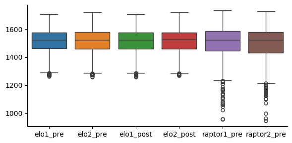

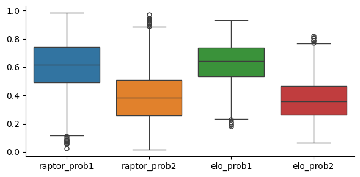

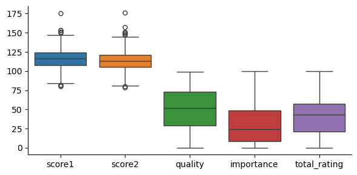

```python
#Statistical summary of every column using numerical components
for col in columns:
    print(elo[col].describe())
#Statistical summary of every column using graphical components
big_cols = ['elo1_pre', 'elo2_pre', 'elo1_post', 'elo2_post', 'raptor1_pre', 'raptor2_pre']
prob_cols = ['raptor_prob1', 'raptor_prob2', 'elo_prob1', 'elo_prob2']
small_cols = ['score1', 'score2', 'quality', 'importance', 'total_rating']
sns.catplot(data=elo[big_cols], kind="box", height=3, aspect=2)
sns.catplot(data=elo[prob_cols], kind="box", height=3, aspect=2)
sns.catplot(data=elo[small_cols], kind="box", height=3, aspect=2)
```

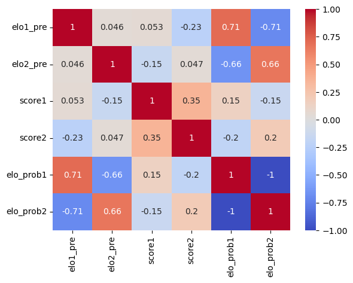

```python
#Correlations between quantitative columns (the heatmap would not fit above)
pairs = elo[['elo1_pre', 'elo2_pre', 'score1', 'score2', 'elo_prob1', 'elo_prob2']]
C = pairs.corr()
sns.heatmap(C, annot=True, cmap='coolwarm', vmin=-1, vmax=1)
```

# Discussion

Two questions about the dataset to explore in future projects

- Categorical outcome: Can elo, elo probability, raptor, and raptor probability predict whether a team makes the playoffs or not
- Quantitative outcome: What percentage of important games (games with an importance of 75 or greater) can elo, elo probability, raptor, and raptor probability correctly predict?